# Reputation_ds_challenge_Madhura_Bartakke

```python
# Check the python version
from platform import python_version
print("Python version:", python_version())
```

```
Python version: 3.8.8
```

```python
import numpy as np
import pandas as pd
from collections import Counter
from sklearn.preprocessing import LabelEncoder
from sklearn.model_selection import train_test_split
from sklearn.ensemble import RandomForestClassifier
from sklearn.feature_selection import SelectKBest, f_classif
from sklearn.model_selection import train_test_split, KFold
from sklearn.preprocessing import OneHotEncoder, MinMaxScaler
from sklearn.metrics import accuracy_score, precision_score, recall_score, f1_score, roc_curve, roc_auc_score, confusion_matrix

import matplotlib.pyplot as plt
import matplotlib
import seaborn as sns
sns.set()
```

### Load an get insights from data

```python
#Read the data

reviews_df = pd.read_csv('reviews.csv')

test_reviews_df = pd.read_csv('test_reviews.csv')
```

```python
# Create a copy of raw data for manipulation

df = reviews_df.copy()
```

```python
# Eyeballing the data
with pd.option_context('display.max_rows', 10, 'display.max_columns', df.shape[1]):
    display(df)
```

|  | location_id | review_id | source | date | rating |
| --- | --- | --- | --- | --- | --- |
| 0 | 4962_10 | 115272000000 | FACEBOOK | 3/8/14 | 1.0 |
| 1 | 4962_10 | 63635149969 | GOOGLE_PLACES | 10/5/14 | 1.0 |
| 2 | 4962_10 | 88851130838 | FACEBOOK | 6/2/15 | 1.0 |
| 3 | 4962_10 | 114532000000 | FACEBOOK | 8/12/15 | 1.0 |
| 4 | 4962_10 | 72476500400 | FACEBOOK | 10/24/15 | 1.0 |
| ... | ... | ... | ... | ... | ... |
| 179341 | 4962_993 | 42074113058 | GOOGLE_PLACES | 3/22/18 | 5 |
| 179342 | 4962_993 | 60165851002 | GOOGLE_PLACES | 3/23/18 | 5 |
| 179343 | 4962_993 | 60441942986 | GOOGLE_PLACES | 3/23/18 | 5 |
| 179344 | 4962_993 | 60225154392 | GOOGLE_PLACES | 3/29/18 | 5 |
| 179345 | location_id | review_id | source | date | rating |

179346 rows × 5 columns

```python
# Dropping the last row
df = df[:-1]
```

```python
# structure of data
print("The dataset has {} records with {} fields.".format(*df.shape))
```

```
The dataset has 179345 records with 5 fields.
```

```python
# Columns in the dataset
df.columns
```

```
Index(['location_id', 'review_id', 'source', 'date', 'rating'], dtype='object')
```

```python
# Index, Datatype and Memory information
df.info()
```

```
<class 'pandas.core.frame.DataFrame'>
RangeIndex: 179345 entries, 0 to 179344
Data columns (total 5 columns):
 #   Column       Non-Null Count   Dtype
---  ------       --------------   -----
 0   location_id  179345 non-null  object
 1   review_id    179345 non-null  object
 2   source       179345 non-null  object
 3   date         179345 non-null  object
 4   rating       179276 non-null  object
dtypes: object(5)
memory usage: 6.8+ MB
```

```python
# Converting to datetime datatype
df['date'] = pd.to_datetime(df['date'])
```

```python
#Column wise count of null values
df.isnull().sum()
```

```
location_id     0
review_id       0
source          0
date            0
rating         69
dtype: int64
```

```python
# Checking if there are any duplicates in the data
print("Count of duplicates", len(df)-len(df.drop_duplicates()))

# Drop the duplicates
df = df.drop_duplicates()

# Check the shape of data
print(df.shape)
```

```
Count of duplicates 123
(179222, 5)
```

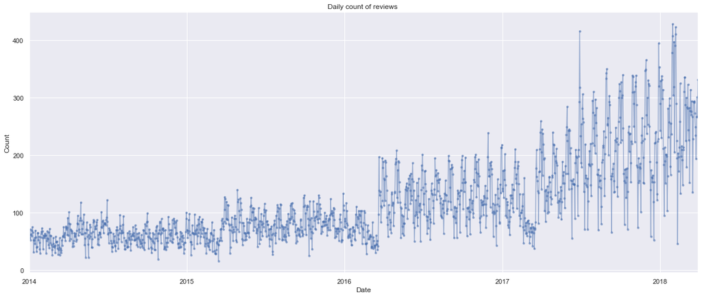

```python
# Creating a data frame of review dates and count of reviews
date_df = df[['date', 'review_id']]
date_df = date_df.sort_values(by='date')

# summing transaction amount at a daily level
date_df = date_df.groupby('date')['review_id'].count().reset_index()
date_df = date_df.set_index('date')

# plotting total daily spending
plt.figure(figsize=(20,8))
date_df['review_id'].plot(alpha=0.5, marker='.', linestyle='-')
plt.title('Daily count of reviews ')
plt.ylabel('Count')
plt.xlabel('Date')
plt.show()
```

From the above time plot we can infer that, daily count of rating was the highest in 2018 followed by 2017.

```python
print("There are {} unique location ids available in the dataset".format(len(df['location_id'].unique())))
```

```
There are 252 unique location ids available in the dataset
```

```python
# Value counts for categorical variable 'source'

source_value_counts = df['source'].value_counts()
source_value_counts
```

```
GOOGLE_PLACES    109641
CARS              43087
FACEBOOK          26494
Name: source, dtype: int64
```

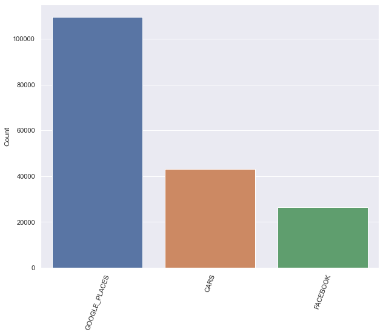

```python
# Check the distribution of target variable 'source'

sns.set(rc={'figure.figsize':(10,8)})
sns.barplot(x=df.source.value_counts().index, y=df.source.value_counts())
plt.xticks(rotation=70)
plt.ylabel("Count")
plt.rcParams["figure.autolayout"] = True
```

```python
# Value counts for categorical variable 'source'

rating_value_counts = df['rating'].value_counts()
rating_value_counts
```

```
5.0    102262
5       37478
1.0     13318
4.0      9841
1        4867
4        3785
3.0      3049
2.0      2502
3        1116
2         935
Name: rating, dtype: int64
```

```python
# Get all rating in one format

df['rating'] = df['rating'].map({5:5.0, 4:4.0, 3:3.0, 2:2.0, 1:1.0})

rating_value_counts = df['rating'].value_counts()
rating_value_counts
```

```
5.0    102262
1.0     13318
4.0      9841
3.0      3049
2.0      2502
Name: rating, dtype: int64
```

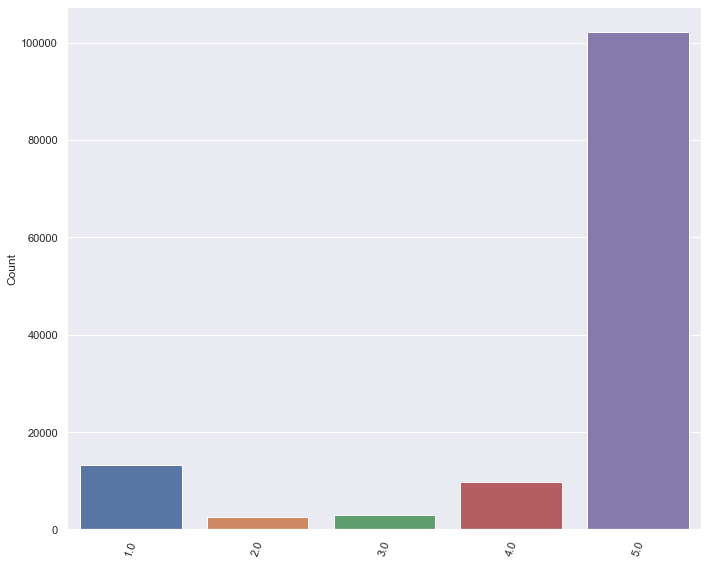

```python
# Check the distribution of target variable 'rating'

sns.set(rc={'figure.figsize':(10,8)})
sns.barplot(x=df.rating.value_counts().index, y=df.rating.value_counts())
plt.xticks(rotation=70)
plt.ylabel("Count")
plt.rcParams["figure.autolayout"] = True
```

```python
# Dropping null values from rating column
df.dropna(subset=['rating'], inplace=True)

# Shpe of the data after dropping
df.shape
```

```
(130972, 5)
```

```python
# Check value counts for review_id

review_id_value_counts = df['review_id'].value_counts()
review_id_value_counts
```

```
112332000000    2
167441000000    2
139227000000    2
162007000000    2
109624000000    2
               ..
24253653117     1
32914827381     1
111135000000    1
167287000000    1
68085600687     1
Name: review_id, Length: 119962, dtype: int64
```

```python
# Lets deep dive into one of the review_id

review_id_df = df[df['review_id'] == '123981000000']
review_id_df
```

|  | location_id | review_id | source | date | rating |
| --- | --- | --- | --- | --- | --- |
| 50728 | 4962_402 | 123981000000 | GOOGLE_PLACES | 2016-06-12 | 1.0 |
| 51509 | 4962_402 | 123981000000 | GOOGLE_PLACES | 2017-07-29 | 5.0 |

From the analysis in the above two cells, we can infer that there are certain review_id having two different entries. For instance, review_id '123981000000' has two entries with rating 1 and 5 in the year 2016 and 2017 respectively. This means that, this location id has been reviewed twice. There are several such records in the data.

```python
# Dropping noisy values from data

df = df[~df['review_id'].str.contains('test_')]
df.shape
```

```
(130778, 5)
```

### Problems

```python
location_id_df = df.groupby('location_id').agg(['mean', 'count']).reset_index()
location_id_df
```

|  | location_id | rating mean | rating count |
| --- | --- | --- | --- |
| 0 | 4962_10 | 4.410653 | 582 |
| 1 | 4962_1000 | 4.462575 | 668 |
| 2 | 4962_1005 | 4.368088 | 633 |
| 3 | 4962_101 | 4.103896 | 847 |
| 4 | 4962_103 | 4.279449 | 798 |
| ... | ... | ... | ... |
| 179 | 4962_751 | 4.571429 | 840 |
| 180 | 4962_753 | 4.648084 | 574 |
| 181 | 4962_755 | 4.238938 | 565 |
| 182 | 4962_764 | 4.499366 | 789 |
| 183 | 4962_765 | 4.543860 | 456 |

184 rows × 3 columns

#### 1.a. Compare the two locations (4962_201 and 4962_380). Which do you think is better? Why?

```python
print("Mean and count for location_id 4962_201 \n\n", location_id_df[location_id_df['location_id']== '4962_201'])
print("\n")
print("Mean and count for location_id 4962_380 \n\n", location_id_df[location_id_df['location_id']== '4962_380'])
```

```
Mean and count for location_id 4962_201

    location_id   rating
                   mean count
27    4962_201  4.75054   926


Mean and count for location_id 4962_380

    location_id    rating
                    mean count
68    4962_380  4.669797   639
```

Location with id 4962_201 is better than location with id 4962_380. Mean rating for location id 4962_201 is 4.75 whch is greater than mean rating for location id 4962_380 which is 4.66. Furthermore if we look at the number of ratings for these location ids, 4962_201 has 926 ratings which is greater than 639 ratings for 4962_380.

#### 1.b. Compare the two locations (4962_381 and 4962_915). Which do you think is better? Why?

```python
print("Mean and count for location_id 4962_381 \n\n", location_id_df[location_id_df['location_id']== '4962_381'])
print("\n")
print("Mean and count for location_id 4962_915 \n\n", location_id_df[location_id_df['location_id']== '4962_915'])
```

```
Mean and count for location_id 4962_381

    location_id    rating
                    mean count
69    4962_381  4.554562   559


Mean and count for location_id 4962_915

 Empty DataFrame
Columns: [(location_id, ), (rating, mean), (rating, count)]
Index: []
```

From the above analysis, we can see that location with id 4962_915 doesn't have any ratings. We cant' make a comparison here.

#### 1.c. Create a formula to rank all of the locations using the data in reviews.csv. Explain how you settled on this ranking/formula. Please also share the formula and the final rankings. (Hint: do not just look at average rating.)

```python
# Scale the continuous variables mean and count between 0 and 1

scaler = MinMaxScaler()
mean_df = df.groupby('location_id').agg('mean').reset_index()
mean_df['mean_rating_scaled'] = scaler.fit_transform(mean_df[['rating']].to_numpy())
mean_df = mean_df[['location_id', 'mean_rating_scaled']]

count_df = df.groupby('location_id').agg('count').reset_index()
count_df['count_rating_scaled'] = scaler.fit_transform(count_df[['rating']].to_numpy())
count_df = count_df[['location_id', 'count_rating_scaled']]

rank_df = mean_df.merge(count_df, on='location_id')

# Take euclidean norm
rank_df['euclidean']= np.sqrt(rank_df['mean_rating_scaled']**2+rank_df['count_rating_scaled']**2)

# Rank the values
rank_df['rank'] = rank_df['euclidean'].rank(ascending=False)
rank_df['rank'] = rank_df['rank'].astype('int')
rank_df = rank_df.sort_values(by=['rank'])
```

```python
rank_df[['location_id', 'rank']]
```

|  | location_id | rank |
| --- | --- | --- |
| 43 | 4962_275 | 1 |
| 86 | 4962_435 | 2 |
| 157 | 4962_708 | 3 |
| 146 | 4962_66 | 4 |
| 27 | 4962_201 | 5 |
| ... | ... | ... |
| 76 | 4962_418 | 180 |
| 112 | 4962_515 | 181 |
| 41 | 4962_267 | 182 |
| 7 | 4962_107 | 183 |
| 131 | 4962_579 | 184 |

184 rows × 2 columns

To rank the location_id, I have considered mean of rating and count of rating. Scaled both the values using MinMax Scaler to get all values into range of 0 to 1. Took square root of sum of squares of scaled mean and count (eucledian). Ranked them in the order of euclidean norm values.

#### 1.d. Briefly describe at least one other analysis or additional data set you would want to incorporate into this ranking if you had access to other data and/or more time.

1. Considered the fact that there are multiple entries for one review_id. Whether we should consider only latest entry or all the entries and why.
2. Should raking only be dependent on average and count of rating?

### Feature Engineering

```python
# Extract year
df['year'] = df['date'].dt.year

df['month'] = df['date'].dt.month
```

```python
# One hot encoing categorical variables
df = pd.get_dummies(df, columns=['source', 'year'])
#df = pd.get_dummies(df, columns=['source', 'year', 'location_id'])
```

```python
target = df['rating']
counter = Counter(target)
for k,v in counter.items():
    per = v / len(target) * 100
    print('Class=%s, Count=%d, Percentage=%.3f%%' % (k, v, per))
```

```
Class=1.0, Count=13302, Percentage=10.171%
Class=2.0, Count=2498, Percentage=1.910%
Class=3.0, Count=3045, Percentage=2.328%
Class=4.0, Count=9822, Percentage=7.510%
Class=5.0, Count=102111, Percentage=78.080%
```

From the above analysis, we can infer that the data i highly imbalance. Ramdom Forest handles imbalance of classes by giving each class equal weightage. We can also use other sampling techniques like upsampling, downsampling, SMOTE to handle the imbalance of classes.

```python
# Spliting the data into input and target

X = df.loc[:, df.columns != 'rating']
y = df.loc[:, df.columns == 'rating']
X = df.drop(['date', 'rating'], axis=1)

print("Shape of input and target variables")
print(X.shape, y.shape)
```

```
Shape of input and target variables
(130778, 11) (130778, 1)
```

```python
# Label Encode target variable y
y = LabelEncoder().fit_transform(y)

y = pd.DataFrame(y)
```

#### 2.a Build a model to predict the rating a reviewer will give a location (the rating field from the reviews file) given the data from all other columns. The goal of the model is not just to predict the most likely rating of any review. We want a model that can accurately predict the average rating across a set of reviews (so please do not just develop a model that predicts 5 for every review just because that is by far the most common rating.) Please describe your model, as well as submit any code you used.

```python
# Split the data using train-test split and stratify
X_train, X_test, y_train, y_test = train_test_split(X, y, test_size=0.25, random_state=42, shuffle=True, stratify=y)
```

```python
# Traning the model with CV
def train_cv( X_train, y_train, model_name, model, cv=5):
    kf = KFold(n_splits=cv,random_state=42, shuffle=True)
    accuracy_list = []
    precision_list = []
    recall_list =[]
    f1score_list =[]
    i=0
    print(model_name)
    print("Performing training with cross validation for ", model_name)
    for train_index, test_index in kf.split(X_train):
        X_cv_train, X_cv_test = X_train.iloc[train_index], X_train.iloc[test_index]
        y_cv_train, y_cv_test = y_train.iloc[train_index], y_train.iloc[test_index]
        y_cv_train = y_cv_train.to_numpy().ravel()
        y_cv_test = y_cv_test.to_numpy().ravel()
        model = model.fit(X_cv_train,y_cv_train)
        y_cv_pred = model.predict(X_cv_test)
        accuracy = accuracy_score(y_cv_test, y_cv_pred)
        precision = precision_score(y_cv_test, y_cv_pred, average='weighted')
        recall = recall_score(y_cv_test, y_cv_pred, average='weighted')
        f1score = f1_score(y_cv_test, y_cv_pred, average='weighted')

        print("Cross validation:{} | Accuracy: {:.4f} | Precision: {:.4f} | Recall: {:.4f} | F-1 score: {:.4f}".format(i+1, accuracy, precision, recall, f1score))
        accuracy_list.append(accuracy)
        precision_list.append(precision)
        recall_list.append(recall)
        f1score_list.append(f1score)
        i+=1
    print('Mean CV Accuracy :', (sum(accuracy_list)/cv))
    print('Mean CV Precision :', (sum(precision_list)/cv))
    print('Mean CV Recall :', (sum(recall_list)/cv))
    print('Mean CV F1-score :', (sum(f1score_list)/cv))
    return model

# Predicting on test set
def predict(model_name, model, X_test, y_test):
    y_test = y_test.to_numpy().ravel()
    print("Predicting on test set for ", model_name)
    y_pred = model.predict(X_test)
    print('Accuracy test:',accuracy_score(y_test, y_pred))
    print('Precision test:' ,precision_score(y_test, y_pred, average='weighted'))
    print('Recall test:' ,recall_score(y_test, y_pred, average='weighted'))
    print('F1-score test:' ,f1_score(y_test, y_pred, average='weighted'))
    return y_test, y_pred
```

```python
# Initializing Random Forest Regressor
model_name = 'Random Forest Classifier'
rfr = RandomForestClassifier(n_estimators=100, class_weight='balanced', random_state=42,  n_jobs = -1)

model_rfr = train_cv(X_train, y_train, model_name, rfr, cv=5)
y_test, y_pred = predict(model_name, model_rfr, X_test, y_test)
```

```
Random Forest Classifier
Performing training with cross validation for  Random Forest Classifier
Cross validation:1 | Accuracy: 0.7123 | Precision: 0.6438 | Recall: 0.7123 | F-1 score: 0.6736
Cross validation:2 | Accuracy: 0.7112 | Precision: 0.6453 | Recall: 0.7112 | F-1 score: 0.6744
Cross validation:3 | Accuracy: 0.7149 | Precision: 0.6554 | Recall: 0.7149 | F-1 score: 0.6818
Cross validation:4 | Accuracy: 0.7146 | Precision: 0.6488 | Recall: 0.7146 | F-1 score: 0.6774
Cross validation:5 | Accuracy: 0.7165 | Precision: 0.6546 | Recall: 0.7165 | F-1 score: 0.6817
Mean CV Accuracy : 0.7139056035851649
Mean CV Precision : 0.6495887393508756
Mean CV Recall : 0.7139056035851649
Mean CV F1-score : 0.6777919819399253
Predicting on test set for  Random Forest Classifier
Accuracy test: 0.7121578222969873
Precision test: 0.6496163194357892
Recall test: 0.7121578222969873
F1-score test: 0.677026416714372
```

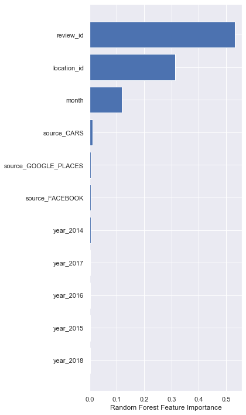

```python
# Feature importance score for Random Forest
sorted_idx = model_rfr.feature_importances_.argsort()
names = [X.columns[i] for i in sorted_idx]

plt.figure(figsize=(6, 10))
plt.barh(names, model_rfr.feature_importances_[sorted_idx])
plt.xlabel("Random Forest Feature Importance")
plt.show()
```

```python
#Utility function to evaluate model predictions against testing data
def model_evaluation(y_pred, y_test):
    print("Evaluating model performance...", "\n")

    cnf_mat = confusion_matrix(y_test,y_pred)
    sns.heatmap(cnf_mat.T, square=True, annot=True, fmt='d', cmap='Blues', cbar=False)
    plt.title('Confusion Matrix')
    plt.xlabel('True label')
    plt.ylabel('Predicted label')
    plt.show()

    print('Accuracy: {}%'.format(round(accuracy_score(y_test, y_pred)*100, 2)))
    print('Precision: {}%'.format(round(precision_score(y_test, y_pred, average='weighted')*100, 2)))
    print('Recall: {}%'.format(round(recall_score(y_test, y_pred, average='weighted')*100, 2)))
    print('F1 Score: {}'.format(round(f1_score(y_test, y_pred, average='weighted'), 1)))
```

```
Evaluating model performance...
```

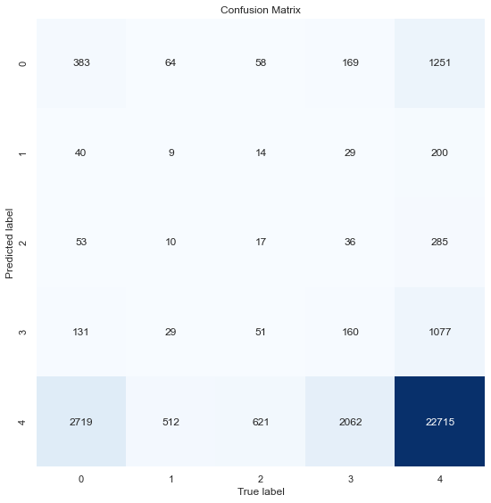

```
Accuracy: 71.22%
Precision: 64.96%
Recall: 71.22%
F1 Score: 0.7
```

```python
#evaluate

model_evaluation(y_pred, y_test)
```

#### b. Please use your model to predict ratings for the reviews in test_reviews.csv and submit those predictions (i.e. submit a version of test_reviews.csv with the 5th column filled in with predicted ratings.)

```python
# Eyeballing the test data
with pd.option_context('display.max_rows', 10, 'display.max_columns', test_reviews_df.shape[1]):
    display(test_reviews_df)
```

|  | location_id | review_id | source | date | rating |
| --- | --- | --- | --- | --- | --- |
| 0 | 4962_147 | test_10368849285 | FACEBOOK | 12/4/15 | NaN |
| 1 | 4962_147 | test_1042394214 | FACEBOOK | 11/29/16 | NaN |
| 2 | 4962_185 | test_11322162891 | GOOGLE_PLACES | 8/3/16 | NaN |
| 3 | 4962_185 | test_11324660949 | GOOGLE_PLACES | 2/3/18 | NaN |
| 4 | 4962_185 | test_11348252095 | GOOGLE_PLACES | 2/12/16 | NaN |
| ... | ... | ... | ... | ... | ... |
| 1382 | 4962_185 | test_8192867949 | FACEBOOK | 11/10/17 | NaN |
| 1383 | 4962_185 | test_8193238229 | FACEBOOK | 11/18/16 | NaN |
| 1384 | 4962_185 | test_8218201172 | FACEBOOK | 7/19/16 | NaN |
| 1385 | 4962_185 | test_8219378940 | FACEBOOK | 12/4/17 | NaN |
| 1386 | 4962_185 | test_8245807617 | FACEBOOK | 1/23/14 | NaN |

1387 rows × 5 columns

```python
# Check if it has any null column

test_reviews_df.isnull().sum()
```

```
location_id     263
review_id       263
source          263
date            263
rating         1387
dtype: int64
```

```python
# Dropping null values from rating column
test_reviews_df.dropna(subset=['location_id'], inplace=True)
```

```python
# Creating a copy for manipulation

result = test_reviews_df.copy()
```

```python
# Converting to datetime datatype
test_reviews_df['date'] = pd.to_datetime(test_reviews_df['date'])

# Extract year
test_reviews_df['year'] = test_reviews_df['date'].dt.year
test_reviews_df['month'] = test_reviews_df['date'].dt.month

# Drop the rating column
test_reviews_df = test_reviews_df.drop(['rating'], axis=1)
test_reviews_df = test_reviews_df.drop(['date'], axis=1)

test_reviews_df['year'] = test_reviews_df['year'].astype(int)

# One hot encoing categorical variables
test_reviews_df = pd.get_dummies(test_reviews_df, columns=['source', 'year'])

# Extrcating rating id from test_review_df rating_id
test_reviews_df['review_id'] = test_reviews_df['review_id'].str.extract('(\d+)')
```

```python
# Predict on unseen data
result['rating'] = model_rfr.predict(test_reviews_df)

result['rating'] = result['rating'].map({4:5, 3:4, 2:3, 1:2, 0:1})

print(result.head())
```

```
  location_id         review_id         source      date  rating
0    4962_147  test_10368849285       FACEBOOK   12/4/15       5
1    4962_147   test_1042394214       FACEBOOK  11/29/16       5
2    4962_185  test_11322162891  GOOGLE_PLACES    8/3/16       5
3    4962_185  test_11324660949  GOOGLE_PLACES    2/3/18       1
4    4962_185  test_11348252095  GOOGLE_PLACES   2/12/16       5
```

```python
# Converting into CSV
result.to_csv("test_reviews_madhura.csv")
```

#### c. Predict the average rating of the 64 ratings for location 4962_442 in test_reviews.csv. More importantly, estimate a 95% confidence interval for this average rating across the 64 ratings for location 4962_442?

```python
result_mean_df = result.groupby('location_id').agg(['mean', 'std']).reset_index()
result_mean_df
```

|  | location_id | rating mean | rating std |
| --- | --- | --- | --- |
| 0 | 4962_147 | 4.927273 | 0.535246 |
| 1 | 4962_185 | 4.838636 | 0.632353 |
| 2 | 4962_221 | 4.800000 | 0.861318 |
| 3 | 4962_442 | 5.000000 | 0.000000 |

```python
# Averae rating for location 4962_442
result_mean_df[result_mean_df['location_id'] == '4962_442']
```

|  | location_id | rating mean | rating std |
| --- | --- | --- | --- |
| 3 | 4962_442 | 5.0 | 0.0 |

#### d. Briefly describe one way you think your model could be improved if you had more data and/or more time.

1.I could improve the imbalance situation of the model if I had more data or time.

1. Tune Random Forest Classifier hyperparameters or used RamdomSearchCV to find best parameters

### Appendix

```python
# confusion_matrix(
#     y_test.values.argmax(axis=1), y_pred.argmax(axis=1))
```

```python
# def evaluate_model(X, y, model):
# 	# define evaluation procedure
# 	cv = RepeatedStratifiedKFold(n_splits=5, n_repeats=3, random_state=1)
# 	# evaluate model
# 	scores = cross_val_score(model, X, y, scoring='accuracy', cv=cv, n_jobs=-1)
# 	return scores
```

```python
# from sklearn.model_selection import cross_val_score
# from sklearn.model_selection import RepeatedStratifiedKFold
# from sklearn.ensemble import RandomForestClassifier
# model = RandomForestClassifier(n_estimators=100, class_weight='balanced')
# #fit
# model.fit(X_train, y_train)

# #predict
# y_pred = forest.predict(X_test)

# #evaluate
# model_evaluation(y_pred, y_test)
```

```python
# scores = evaluate_model(X_train, y_train, model)
```

```python
# from numpy import mean
# from numpy import std
# print('Mean Accuracy: %.3f (%.3f)' % (mean(scores), std(scores)))
```

```python
# import numpy as np
# count = y_train.value_counts()
# n_samples = count.median()
# n_samples
```

```python
# def sampling_strategy(X,y,n_samples, t='majority'):
#     target_classes = ''
#     if t == 'majority':
#         target_classes = y.value_counts() > n_samples
#     elif t == 'minority':
#         target_classes = y.value_counts() < n_samples
#     tc = target_classes[target_classes == True].index
#     #target_classes_all = y.value_counts().index
#     sampling_strategy = {}
#     for target in tc:
#         sampling_strategy[target] = n_samples
#     return sampling_strategy
```

```python
# # X = df[['location_id', 'review_id', 'source', 'date']]
# # y = df[['rating']]
# # #get correlations of each features in dataset
# # corrmat = df.corr()
# # top_corr_features = corrmat.index
# # plt.figure(figsize=(20,20))
# # #plot heat map
# # g=sns.heatmap(df[top_corr_features].corr(),annot=True,cmap="RdYlGn")

# fig, ax = plt.subplots(figsize=(12,12))
# sns.heatmap(df.corr()[['rating']].sort_values('rating').tail(10),
#  vmax=1, vmin=-1, cmap='YlGnBu', annot=True, ax=ax);
# ax.invert_yaxis()

# # corr=df.corr()
# # plt.subplots(figsize=(20,15))
# # sns.heatmap(corr)
```

```python
# test_reviews_df['location_id']
# # remove nan from test
```

```python
# groupby =test_reviews_df.groupby('location_id')
# print(groupby.head())
```

```python
# df["location_id"] = df["location_id"].astype('category')
# df.dtypes

# df["location_id"] = df["location_id"].cat.codes
# df.head()
```

```python
# # # Select best features using ANOVA F-value between label and features

# selector = SelectKBest(f_classif, k=100).fit(X, y.to_numpy().ravel())
# #sorted_idx = model_rfr.feature_importances_.argsort()


# # Plot feature scores
# feature_df = pd.DataFrame()
# feature_df['feature'] = X.columns
# feature_df['score'] = selector.scores_

# #sort by feature importance
# feature_df = feature_df.sort_values(by='score').reset_index(drop=True)

# # Plot F-value of most important features
# #plt.figure(figsize=(6, 9))
# plt.barh(y=feature_df.loc[:100,]['feature'], width=feature_df.loc[:100,]['score'])
# plt.title('ANOVA F-value between label and features - top 15 variables')
# plt.xlabel('F-value')
# plt.show()

# # Identify most important features
# features = selector.get_support()

# # # Transform feature matrix
# X = X.loc[:,features]
```